# Estadística descriptiva

**Estadística descriptiva**

*Unidad 5*

## Estadísticos descriptivos de R base

Las funciones que calculan medidas de tendencia central, de dispersión y de posición, que son parte integral del lenguaje R, como `mean()`, `sd()` o `max()`, se aplican sobre vectores o variables de un dataframes (internamente funcionan igual), utilizando estructuras de tidyverse como el `summarise()`.

Asociadas al `group_by()`, o a la inclusión del argumento `.by =` dentro de `summarise()`, se obtiene estos resultados estratificados por categorías de variables cualitativas (las usamos para agrupar).

Esta tarea conlleva escribir una línea de código por cada variable.

## Operaciones simultáneas por columnas

La filosofía de trabajo de **tidyverse** se plantea *nunca copiar y pegar más de dos veces* el código escrito, pero cuando necesitamos realizar la misma operación en un conjunto de variables simultáneamente nos encontramos con este problema.

La solución, ofrecida dentro de **dplyr**, es un andamiaje que permite aplicar funciones y expresiones a varias columnas simultáneamente.

Es una forma de **iteración**, donde se repite la misma acción en diferentes objetos. En este caso los objetos serán columnas (*variables*) de la tabla de datos.

Las operaciones simultáneas pueden darse como transformación (dentro de un `mutate()`) o de resumen (dentro de un `summarise()`)

## Operaciones simultáneas por columnas

Creación de múltiples columnas con **mutate()**

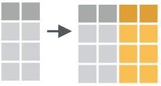

Resumiendo múltiples columnas con **summarise()**

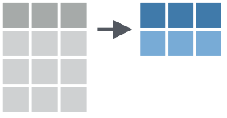

## Función across()

La función `across()` es la encargada de dar soporte a estas operaciones múltiples (*dplyr >= 1.0.0*).

```r
across(.cols,  .fns,  ...,  .names)
```

`.cols` = columnas a transformar

`.fns` = función o funciones para aplicar a cada columna de `.cols`

`...` = argumentos adicionales de las funciones especificadas anteriormente (*ejemplo*: na.rm = T)

`.names` = nombres de las columnas de salida. Aquí, `{.col}` es un marcador especial al que se le puede agregar el sufijo deseado.

## Resúmenes múltiples

Tomemos la siguiente tabla de datos ficticios de resultados de laboratorio (mostramos las primeras 4 observaciones):

```
# A tibble: 4 × 5
     ID Sexo  Colesterol Glucemia Trigliceridos
  <dbl> <chr>      <dbl>    <dbl>         <dbl>
1     1 Mujer        121       60            70
2     2 Mujer        151      116           189
3     4 Varón        105       71            45
4     8 Mujer        183       86           155
```

Supongamos que queremos calcular la media de cada variable…

## Resúmenes múltiples

Podríamos hacerlo repitiendo para cada variable

```r
ENT |> summarise(
  media_colesterol = mean(Colesterol),
  meda_glucemia = mean(Glucemia),
  media_trigliceridos = mean(Trigliceridos)
)
```

```
# A tibble: 1 × 3
  media_colesterol meda_glucemia media_trigliceridos
             <dbl>         <dbl>               <dbl>
1             156.          96.2                117.
```

Pero esto rompe la regla general que buscamos de nunca copiar y pegar más de dos veces…

## Resúmenes múltiples

Para solucionarlo aplicamos `across()` y realizamos el resumen simultáneo en una sola línea.

```r
ENT  |> summarise(
  across(.cols = Colesterol:Trigliceridos, .fns = mean))
```

```
# A tibble: 1 × 3
  Colesterol Glucemia Trigliceridos
       <dbl>    <dbl>         <dbl>
1       156.     96.2          117.
```

Nótese que el primer argumento es el rango de nombres de variables y el segundo la función que aplicamos a todas ellas (*nombres de funciones sin paréntesis*).

## Seleccionar variables (**.cols**)

El primer argumento de `across()` responde de la misma forma que la función `select()` y aplican también las *funciones ayudantes de selección*.

```r
names(ENT)
```

```
[1] "ID"            "Sexo"          "Colesterol"    "Glucemia"
[5] "Trigliceridos"
```

```r
ENT |>
  select(-ID) |>
  group_by(Sexo) |>
  summarise(across(everything(), mean))
```

```
# A tibble: 2 × 4
  Sexo  Colesterol Glucemia Trigliceridos
  <chr>      <dbl>    <dbl>         <dbl>
1 Mujer       155.     92.3          115.
2 Varón       156.    104.           122.
```

## Recordamos a las funciones ayudantes de selección

- `everything()`: coincide con todas las variables.
- `group_cols()`: seleccione todas las columnas de agrupación.
- `starts_with()`: comienza con un prefijo.
- `ends_with()`: termina con un sufijo.
- `contains()`: contiene una cadena literal.
- `matches()`: coincide con una expresión regular.
- `num_range()`: coincide con un rango numérico como x01, x02, x03.
- `all_of()`: coincide con nombres de variables en un vector de caracteres. Todos los nombres deben estar presentes; de lo contrario, se generará un error de fuera de límites.
- `any_of()`: igual que `all_of()`, excepto que no se genera ningún error para los nombres que no existen.
- `where()`: aplica una función a todas las variables y selecciona aquellas para las cuales la función regresa TRUE.

## Expresiones de selección

El argumento `.cols` también puede recibir construcciones *booleanas* utilizando los operadores conocidos como `!` (negación) y conectores lógicos como `&` (AND) y `|` (OR) entre las funciones ayudantes de selección.

Por ejemplo:

```r
.cols = !where(is.numeric) & starts_with("a")
```

Selecciona todas las columnas no numéricas, cuyo nombre comienza con “a”.

## Agregar argumentos a las funciones

Hasta ahora vimos el ejemplo de aplicar una función simple como `mean()` a un grupo de variables.

Que sucede si entre los datos de esas variables hay valores **NA**?

Vamos a necesitar incorporar el argumento `na.rm = TRUE` a la función.

Donde lo hacemos dentro de un `across()`?

## Agregar argumentos a las funciones

Supongamos que tenemos estos datos (mostramos algunas observaciones):

```
# A tibble: 4 × 5
     ID Sexo  Colesterol Glucemia Trigliceridos
  <dbl> <chr>      <dbl>    <dbl>         <dbl>
1   222 Mujer        293       92           435
2   411 Varón        312      341          1134
3    13 Varón         NA       NA            NA
4    22 Mujer         NA      107            85
```

Vemos algunos valores **NA** entre las observaciones.

## Agregar argumentos a las funciones

Si aplicamos el mismo código de `across()` anterior tendríamos como resultado:

```r
datos |>
  summarise(
    across(Colesterol:Trigliceridos, mean)
  )
```

```
# A tibble: 1 × 3
  Colesterol Glucemia Trigliceridos
       <dbl>    <dbl>         <dbl>
1         NA       NA            NA
```

Sería bueno que le pasaramos `na.rm = TRUE` a la función `mean()`.

## Agregar argumentos a las funciones

Existen dos formas sintácticas de hacerlo.

- Una función estilo-purrr (tidyverse): `~ mean(.x, na.rm = TRUE)`
- Una función anónima (base): `function(x) mean(x, na.rm = TRUE)` ; o mejor en su forma de atajo: `\(x) mean(x, na.rm = TRUE)`

```r
datos |>
  summarise(
    across(Colesterol:Trigliceridos, \(x) mean(x, na.rm = TRUE)))
```

```
# A tibble: 1 × 3
  Colesterol Glucemia Trigliceridos
       <dbl>    <dbl>         <dbl>
1       156.     96.2          117.
```

## Múltiples funciones

Para incorporar más de una función dentro de `across()` debemos incluirlas dentro de una lista [`list()`]

```r
datos |>
  summarise(
    across(Colesterol:Trigliceridos, list(
      media = \(x) mean(x, na.rm = TRUE),
      n_na = \(x) sum(is.na(x)))))
```

```
# A tibble: 1 × 6
  Colesterol_media Colesterol_n_na Glucemia_media Glucemia_n_na
             <dbl>           <int>          <dbl>         <int>
1             156.               2           96.2             1
# ℹ 2 more variables: Trigliceridos_media <dbl>, Trigliceridos_n_na <int>
```

La lista contiene cada función a aplicar, bajo nombres definidos.

## Cambiar nombres de resultados

Observemos que los nombres de las variables resultado se componen del nombre de la columna, un guión bajo y el nombre definido de la función aplicada, para distinguir entre las múltiples funciones del `across()`.

La estructura de estos nombres se pueden modificar con el argumento `.names` de `across()`.

Los marcadores especiales para el nombre de columna es `{.col}` y para el nombre de la función definida es `{.fn}`.

## Cambiar nombres de resultados

Por ejemplo, podríamos invertir el orden predeterminado de los nombres del resumen.

```r
datos |>
  summarise(
    across(Colesterol:Trigliceridos, list(
      media = \(x) mean(x, na.rm = TRUE),
      n_na = \(x) sum(is.na(x))),
      .names = "{.fn}_{.col}"))
```

```
# A tibble: 1 × 6
  media_Colesterol n_na_Colesterol media_Glucemia n_na_Glucemia
             <dbl>           <int>          <dbl>         <int>
1             156.               2           96.2             1
# ℹ 2 more variables: media_Trigliceridos <dbl>, n_na_Trigliceridos <int>
```

## Transformación de tipos de datos

Hasta ahora vimos como funciona la función `across()` dentro de un resumen (`summarise`) pero al comienzo también dijimos que se puede utilizar para transformaciones masivas de datos.

Para lograr esto la función se vincula con `mutate()` modificando las variables originales o bien creando nuevas variables si cambiamos su nombre con `.names`.

## Transformación de tipos de datos

Aplicamos la función `log()` para calcular el logaritmo de los valores de las todas las variables.

```r
datos |>
  mutate(
    across(Colesterol:Trigliceridos, log)) |>
  slice_head(n = 4) # vemos las primera 4 observaciones
```

```
# A tibble: 4 × 5
     ID Sexo  Colesterol Glucemia Trigliceridos
  <dbl> <chr>      <dbl>    <dbl>         <dbl>
1   321 Mujer       4.28     4.19          4.06
2   292 Mujer       4.30     4.20          4.13
3   181 Mujer       4.39     4.56          4.06
4   229 Mujer       4.41     4.84          3.83
```

## Transformación de tipos de datos

Hacemos lo mismo pero cambiamos los nombres de las variables de salida del `mutate()` que van a coexistir con las originales.

```r
datos |>
  mutate(
    across(Colesterol:Trigliceridos, log,
      .names = "{.col}_log")) |>
  slice_head(n = 4) # vemos las primera 4 observaciones
```

```
# A tibble: 4 × 8
     ID Sexo  Colesterol Glucemia Trigliceridos Colesterol_log Glucemia_log
  <dbl> <chr>      <dbl>    <dbl>         <dbl>          <dbl>        <dbl>
1   321 Mujer         72       66            58           4.28         4.19
2   292 Mujer         74       67            62           4.30         4.20
3   181 Mujer         81       96            58           4.39         4.56
4   229 Mujer         82      127            46           4.41         4.84
# ℹ 1 more variable: Trigliceridos_log <dbl>
```

## Filtros

En el caso de iteraciones similares para incluir dentro de la función `filter()` el paquete dplyr propone dos funciones específicas: `if_any()` e `if_all()`.

En el primer caso, la función enmascara una repetición de OR lógicos y en la segunda una secuencia de AND lógicos.

## Filtros

```r
datos |>
  filter(if_any(Colesterol:Trigliceridos, is.na))
```

```
# A tibble: 2 × 5
     ID Sexo  Colesterol Glucemia Trigliceridos
  <dbl> <chr>      <dbl>    <dbl>         <dbl>
1    13 Varón         NA       NA            NA
2    22 Mujer         NA      107            85
```

Es lo mismo que `filter(is.na(a) | is.na(b) | is.na(c) | is.na(d))`

## Filtros

```r
datos |>
  filter(if_all(Colesterol:Trigliceridos, is.na))
```

```
# A tibble: 1 × 5
     ID Sexo  Colesterol Glucemia Trigliceridos
  <dbl> <chr>      <dbl>    <dbl>         <dbl>
1    13 Varón         NA       NA            NA
```

Es lo mismo que `filter(is.na(a) & is.na(b) & is.na(c) & is.na(d))`

## Filtros

Las dos funciones de filtro trabajan con el mismo esquema que `across()`, por lo tanto se le puede aplicar una función o expresión de condición (debe devolver `TRUE` o `FALSE`)

```r
datos |>
  filter(if_all(Colesterol:Trigliceridos, \(x) x > 140 & x < 200))
```

```
# A tibble: 2 × 5
     ID Sexo  Colesterol Glucemia Trigliceridos
  <dbl> <chr>      <dbl>    <dbl>         <dbl>
1    83 Mujer        163      179           159
2   415 Mujer        194      166           186
```

## Paquete rstatix

El paquete `rstatix` simplifica el proceso de realizar análisis estadísticos complejos.

- sintaxis intuitiva y basada en el paradigma de la *“gramática de datos”* de tidyverse
- permite realizar pruebas estadísticas comunes, como t-tests, ANOVA, y correlaciones, de manera rápida y eficiente
- diseño que facilita la integración de resultados en flujos de trabajo de análisis reproducibles, asegurando que las conclusiones derivadas de los datos sean robustas y transparentes.

## Paquete rstatix

- Muchas de sus funciones son espejos de las funciones estadísticas de R base pero compatibles con tidyverse, por lo que siempre devuelven los resultados en dataframes

```r
library(rstatix)

datos |>
  t_test(Edad ~ Sexo)
```

```
# A tibble: 1 × 8
  .y.   group1 group2    n1    n2 statistic    df     p
* <chr> <chr>  <chr>  <int> <int>     <dbl> <dbl> <dbl>
1 Edad  Mujer  Varon     29    33    -0.871  59.6 0.387
```

Lo que nos permite conectar el resultado mediante tuberías hacia otras funciones del tidyverse, como `select()` o `filter()`.

## Paquete rstatix

Tiene dos funciones de resumenes para variables cuantitativas y cualitativas:

```r
datos |> get_summary_stats(Edad, type = "mean_sd")
```

```
# A tibble: 1 × 4
  variable     n  mean    sd
  <fct>    <dbl> <dbl> <dbl>
1 Edad        62  58.6  24.5
```

```r
datos |> get_summary_stats(Edad, type = "median_iqr")
```

```
# A tibble: 1 × 4
  variable     n median   iqr
  <fct>    <dbl>  <dbl> <dbl>
1 Edad        62   62.5    40
```

## Paquete rstatix

```r
datos |> group_by(Sexo) |>
  get_summary_stats(Edad, type = "common")
```

```
# A tibble: 2 × 11
  Sexo  variable     n   min   max median   iqr  mean    sd    se    ci
  <chr> <fct>    <dbl> <dbl> <dbl>  <dbl> <dbl> <dbl> <dbl> <dbl> <dbl>
1 Mujer Edad        29    18    93     57    39  55.7  23.9  4.44  9.10
2 Varon Edad        33    19    99     63    41  61.1  25.1  4.37  8.90
```

```r
datos |> freq_table(Sexo)
```

```
# A tibble: 2 × 3
  Sexo      n  prop
  <chr> <int> <dbl>
1 Mujer    31  46.3
2 Varon    36  53.7
```

## Paquete janitor

El paquete janitor tiene numerosas funciones de las cuales vamos a destacar la familia **tabyl**.

La función `tabyl()` permite crear tablas de frecuencia de una variable o tablas de contingencia para dos o más variables categóricas.

El paquete además tiene otras funciones que se enlazan con tabyl para personalizar los resultados en estas tablas (por ejemplo, agregar totales o representar frecuencias realtivas como porcentajes)

## Paquete janitor

Se puede personalizar la tabla conectando por tuberías el agregado de otras funciones del paquete.

```r
library(janitor)
datos  |>
  tabyl(Sexo) |>
  adorn_totals(where = "row") |>
  adorn_pct_formatting(digits = 2)
```

```
  Sexo  n percent
 Mujer 31  46.27%
 Varon 36  53.73%
 Total 67 100.00%
```

Incorporamos totales con `adorn_totals()` y configuramos los porcentajes con `adorn_pct_formatting()`.

## gtsummary

Este paquete permite crear tablas de resumen elegantes y personalizables que destacan las estadísticas descriptivas, resultados de modelos, y comparaciones de grupos.

Estas tablas son convenientes para reportes, publicaciones y presentaciones, asegurando que la información clave sea fácilmente comprensible.

Las salidas buscan producir estéticas compatibles con las tablas que se envían a publicar en la mayoría de las revistas científicas, así como también en otras publicaciones similares.

## gtsummary

Un ejemplo de una tabla descriptiva con variables cuanti y cuali estratificada por Sexo.

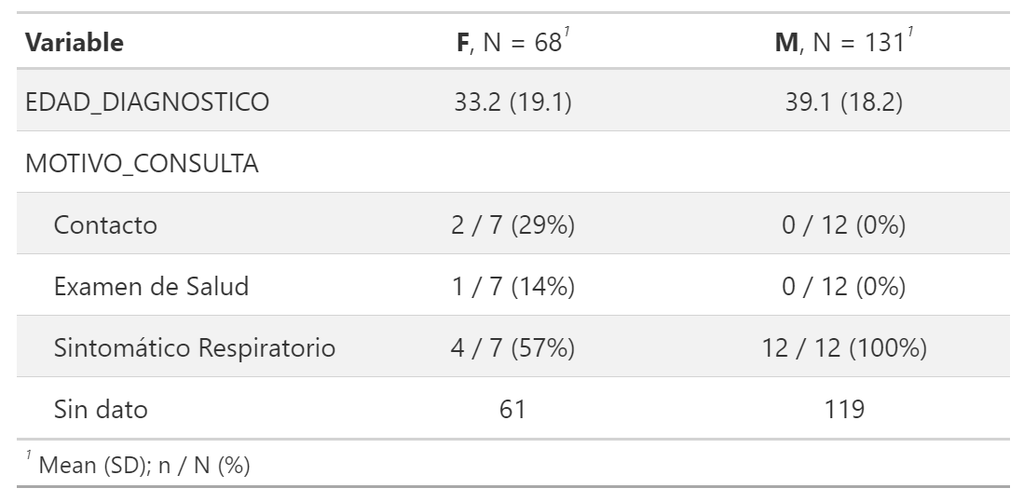

## gtsummary

Tiene 3 funciones principales

- `tbl_summary()`: Calcula estadísticas descriptivas para variables continuas, categóricas y dicotómicas.
- `tbl_regression()`: Convierte un objeto de modelo de regresión en una tabla formateada y personalizada.
- `tbl_survfit()`: Convierte un objeto survfit (supervivencia) en una tabla personalizada con estimaciones de tiempo hasta el evento.

## gtsummary

En la función del ejemplo anterior `tbl_summary()`, se puede personalizar la salida con:

- Variable categórica de estratificación/agrupamiento
- Etiqueta de variables
- Estadísticos a mostrar en variables cuantitativas y cualitativas
- Definir cantidad de digitos en redondeo
- Valores ausentes: no tenerlos en cuenta o cambiarle la etiqueta
- Ordenamientos
- Agregar valores p de test estadísticos entre grupos
- etc.

## flextable

Este paquete es similar a otras librerías como **gt**, **huxtable**, **kableExtra**, etc, que transforman las tablas y dataframes de R en salidas elegantes.

La documentación oficial dice *“crear tablas flexibles y altamente personalizables en formatos de Microsoft Word, PowerPoint y HTML”.*

La elección de este paquete sobre las otras opciones tiene que ver con la amplitud de opciones en la compatibilidad de los formatos de salida.

Las funciones del paquete se integran facilmente con Quarto

## flextable

Una tablita que creamos anteriormente con `freq_table()` de **rstatix** fue:

```r
datos |> freq_table(Sexo)
```

```
# A tibble: 2 × 3
  Sexo      n  prop
  <chr> <int> <dbl>
1 Mujer    31  46.3
2 Varon    36  53.7
```

La salida tradicional de consola se visualiza estéticamente fea.

## flextable

Con flextable podemos configurar esa misma tabla, para mejorar su presentación:

```r
library(flextable)

datos |>
  freq_table(Sexo) |>
  flextable() |> # convertir a flextable
  fontsize(size = 30, part = "all") |>  # modificar tamaño de fuente
  align(align = "center", part = "all") |>  # alinear textos
  line_spacing(space = 2, part = "all") |> # espacios en filas y columnas
  padding(padding = 6, part = "header") |> # espacio en titulo
  set_header_labels(n = "Frecuencia", prop = "%") |> # cambiar cabecera
  theme_zebra() # agregar tema tipo zebra
```

## flextable

| Sexo | Frecuencia | % |
| --- | --- | --- |
| Mujer | 31 | 46.3 |
| Varon | 36 | 53.7 |